# Ajustement d’une V.A discrète par adjustr

Abdessabour MOUTIK

2020-07-30

La variable aléatoire **X** a étudié est le nombre de sinistres. D’abord, nous importons le fichier `nombresinistre30.csv` a notre session R on utilisons la fonction `read.csv` :

```r
db.nbrsin <- read.csv2(path)
```

On affecte la deuxième colone de `db.nbrsin` a notre vecteur `x`

```r
x <- db.nbrsin[[2]]
```

On a l’espérance et la variance de X sont :
$$\bar{X} = 1.78826086956522 \quad \text{ET} \quad \hat\sigma^2_X = 0.969066134614294$$

On remarque que
$$\bar{X} > \hat\sigma^2_X$$
donc la distribution la mieux ajustée peut être celle d’une loi **binomiale**.

J’appelle alors ma fonction `getgoodfit` qui retourne une liste contenant l’*estimation*, les *effectifs théorique*, le *vecteur de probabilté*, le *degré de liberté*, la *p-value*, et l’*$\tilde{\chi}$<sup>2</sup>* pour les distributions données dans la colonne `distributions` du résultat. Simultanément, cette fonction crée le diagramme à barres des *effectifs observés* et les rootogrammes suspendus pour chaque ajustement.

```r
result <- getgoodfit(x, short=FALSE, plots.as.vars = TRUE)
```

```
## [1] "Error occured whilst estimating the size n = NA of the negative binomial distribution."
```

Les distributions utilisées sont :

```r
result$distributions
```

```
## [1] "pois"   "binom"  "nbinom"
```

On trace l’histogramme des nombres de sinistres **X**.

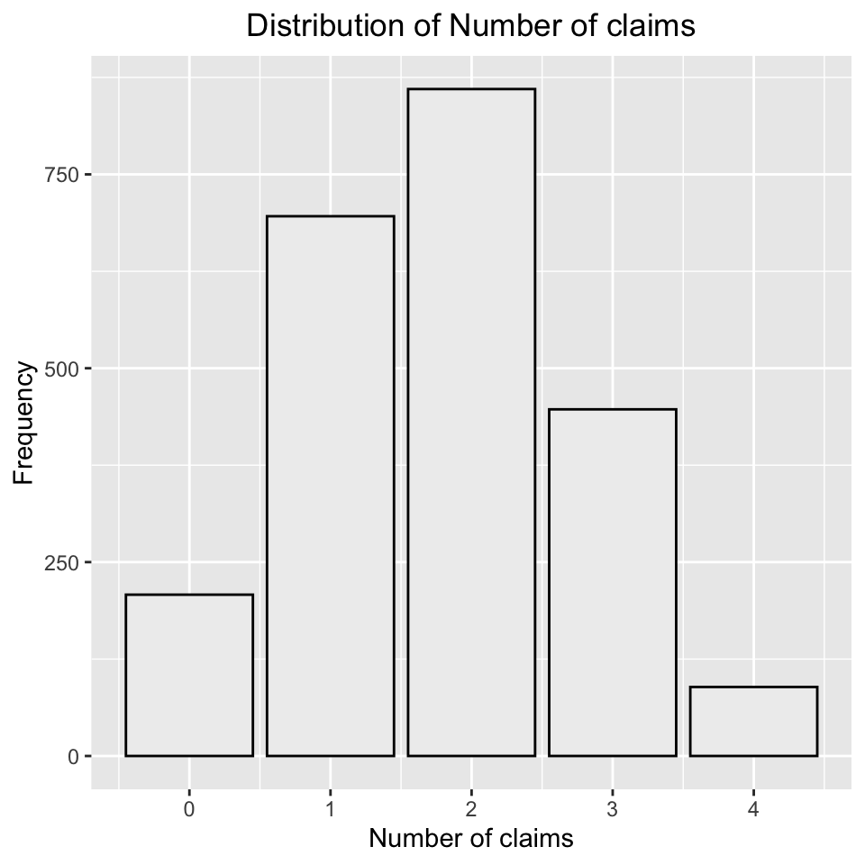

Distribution des Nombre de sinistres

```r
result$Xplot
```

# Ajustement par une distribution de loi de poisson

Après avoir utilisé `vcd::goodfit(x, "pois")` pour obtenir la distribution de poisson ajustée dans le corps de notre fonction `getgoodfit`. On retrouvera l’*estimation* suivantes:

```r
result$pois$estimate
```

```
## $lambda
## [1] 1.788261
```

On affiche le rootograme suspendu :

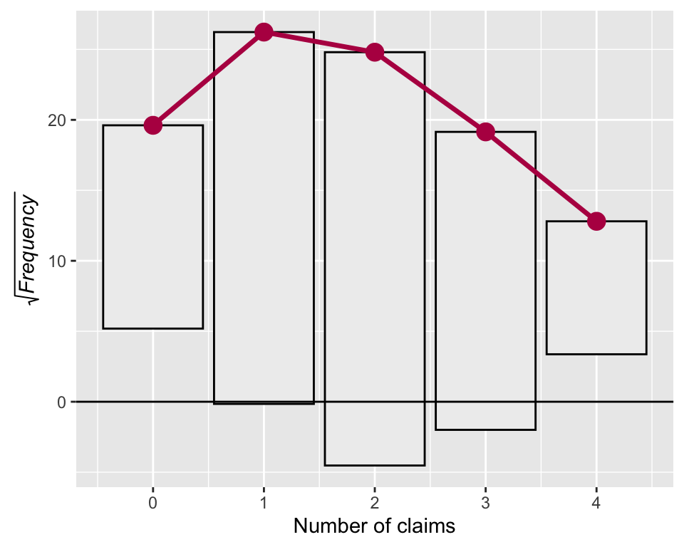

Ajustement par une distrubition $\sim \mathcal{P} \left(1.79\right)$

```r
result$pois$plot
```

On affiche les valeurs de **X**, les *effectifs théoriques*, les *effectifs observés* et le *vecteur de probabilté* :

```r
result$pois
```

| X | Effectif Obserevé | Effectif Ajusté | Probabilité |
| --- | --- | --- | --- |
| 0 | 208 | 384.677 | 0.167 |
| 1 | 696 | 687.902 | 0.299 |
| 2 | 860 | 615.075 | 0.267 |
| 3 | 447 | 366.638 | 0.159 |
| 4 | 89 | 163.911 | 0.107 |

En utilisant le test de $\tilde{\chi}$<sup>2</sup><sub>3</sub> on retrouvera la
$$pvalue = 0$$
et
$$\tilde{\chi}^2 = 296.33091310395$$

Le 95<sup>e</sup> centile d’une loi $\chi^2_{3}$
$$\chi^2_{3}(95\%) = 7.81472790325118$$

on a donc
$$\tilde{\chi}^2 > \chi^2_{3}(95\%)$$
et
$$pvalue < 5\%$$

On rejete l’hypthèse Nulle $\mathcal{H}_0$. Donc la distribution de loi **de poisson** ne permet pas de modèlisé celle de **X**.

# Ajustement par une distribution de loi binomiale

Après avoir utilisé `vcd::goodfit(x, "binom", size=4)` pour obtenir la distribution binomiale ajustée dans le corps de notre fonction `getgoodfit`. On retrouvera l’*estimation* suivantes:

```r
result$binom$estimate
```

```
## $prob
## [1] 0.4470652
##
## $size
## [1] 4
```

On affiche le rootograme suspendu :

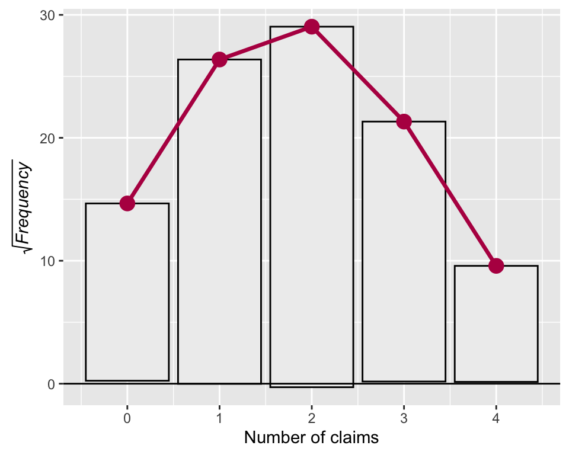

Ajustement par une distrubition $\sim \mathcal{B} \left(0.45, 4\right)$

```r
result$binom$plot
```

On remarque que la distribution binomiale est la mieux ajustée à la distribution de **X**.

On affiche les valeurs de **X**, les *effectifs théoriques*, les *effectifs observés* et le *vecteur de probabilté* :

```r
result$binom
```

| X | Effectif Obserevé | Effectif Ajusté | Probabilité |
| --- | --- | --- | --- |
| 0 | 208 | 214.993 | 0.093 |
| 1 | 696 | 695.313 | 0.302 |
| 2 | 860 | 843.274 | 0.367 |
| 3 | 447 | 454.542 | 0.198 |
| 4 | 89 | 91.878 | 0.040 |

En utilisant le test de $\tilde{\chi}$<sup>2</sup><sub>2</sub> on retrouvera la
$$pvalue = 0.678694205378728$$
et
$$\tilde{\chi}^2 = 0.775169226266107$$

Le 95<sup>e</sup> centile d’une loi $\chi^2_{2}$
$$\chi^2_{2}(95\%) = 5.99146454710798$$

on a donc
$$\tilde{\chi}^2 < \chi^2_{2}(95\%)$$
et
$$pvalue > 5\%$$

On accepte l’hypothèse Nulle $\mathcal{H}_0$. Donc la distribution de loi **binomiale** permet de bien modéliser la distribution la valeur aléatoire **X**.

# Ajustement par une distribution de loi binomiale négative

Après avoir utilisé `vcd::goodfit(x, "nbinom", size=4)` pour obtenir la distribution binomiale négative ajustée dans le corps de notre fonction `getgoodfit`. On retrouvera l’*estimation* suivantes:

```r
result$nbinom$estimate
```

```
## $size
## [1] 4
##
## $prob
## [1] 0.6910539
```

On affiche le rootograme suspendu :

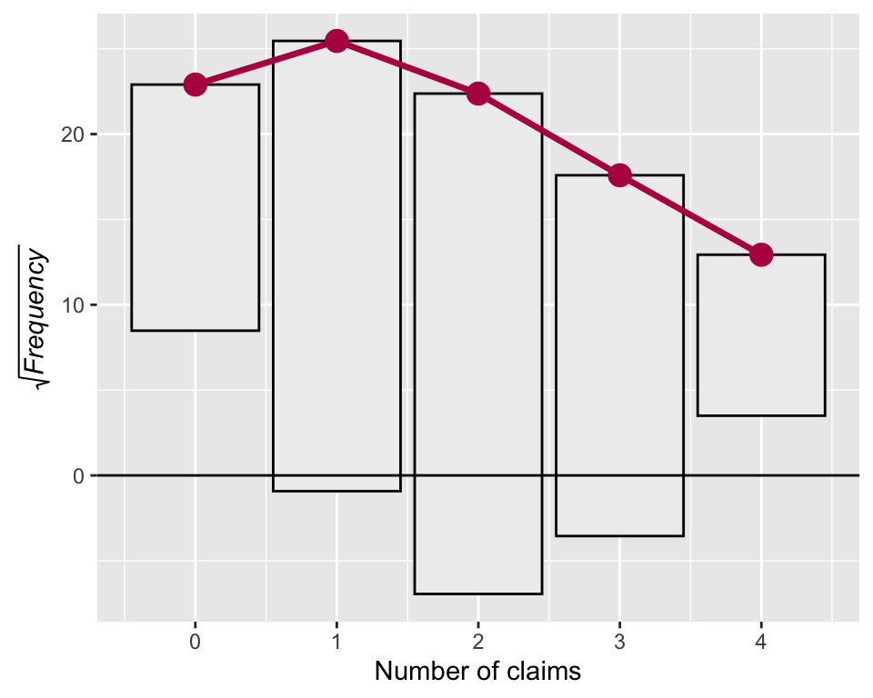

Ajustement par une distrubition $\sim \mathcal{NB} \left(4, 0.69\right)$

```r
result$nbinom$plot
```

On affiche les valeurs de **X**, les *effectifs théoriques*, les *effectifs observés* et le *vecteur de probabilté* :

```r
result$nbinom
```

| X | Effectif Obserevé | Effectif Ajusté | Probabilité |
| --- | --- | --- | --- |
| 0 | 208 | 524.536 | 0.228 |
| 1 | 696 | 648.214 | 0.282 |
| 2 | 860 | 500.658 | 0.218 |
| 3 | 447 | 309.353 | 0.135 |
| 4 | 89 | 167.253 | 0.138 |

En utilisant le test de $\tilde{\chi}$<sup>2</sup><sub>2</sub> on retrouvera la
$$pvalue = 0$$
et
$$\tilde{\chi}^2 = 677.908769377782$$

Le 95<sup>e</sup> centile d’une loi $\chi^2_{2}$
$$\chi^2_{2}(95\%) = 5.99146454710798$$

on a donc
$$\tilde{\chi}^2 > \chi^2_{2}(95\%)$$
et
$$pvalue < 5\%$$

On rejete l’hypthèse Nulle $\mathcal{H}_0$. Donc la distribution de loi **binomiale négative** ne permet pas de modèlisé celle de **X**.

## *Conclusion :* La distribution la mieux ajustée est celle de la loi binomiale

On écrit :
$$\mathbf{X}\sim\mathcal{B}(0.45, 4)$$